# Draft of Figures for Access Paper

Malavika Rajeev

12/19/2018

## Goals of this analysis

- To estimate burden of rabies in Madagascar using nationally available bite patient data
- To explore the potential impacts of expanded access to PEP in Madagascar

## Summary of analyses: Data

- Cleaning data
- excluded contacts with suspect cases
- estimated clinic level underreporting (i.e. incomplete submission of forms)
- average number of annual bites corrected by clinic level underreporting at the district level
- Travel times
- calculated weighted mean of travel times by human population summed to the commune level
- For each clinic, we defined the catchment area as all communes for which the clinic was the closest ARMC.

## Figure 1: Catchment network and distribution of patient travel

[figure not shown]

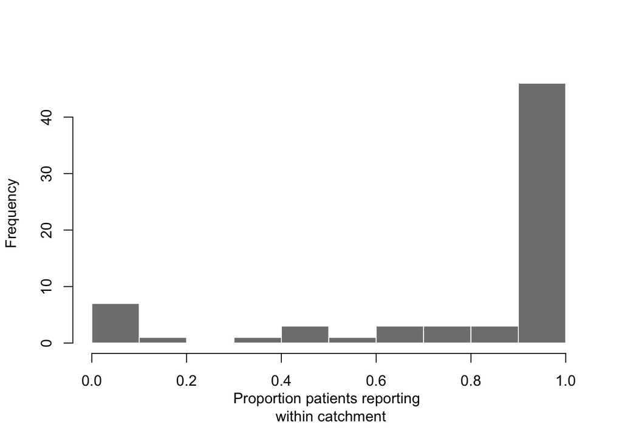

## Figure 2: Adjustment for reporting

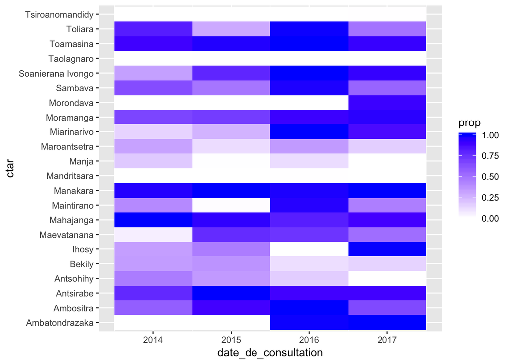

## Summary of analyses: Models of bites as a function of travel time, Moramanga District

- Moramanga models to the commune level:
  $$\mu_{j} = exp(\beta_{t}T_{j} + \beta_{0})\times pop_{j}$$
  $\mu_{j}$ = the mean number of bites in commune $j$
- We then estimate the likelihood of observing the bites at the commune level at the Moramanga clinic where bites are a poisson distribution around the mean $\mu_{j}$

## Summary of analyses: Extending this to the district level

- Moramanga models to the commune level:
  $$\mu_{d} = \sum \limits_{j=1}^jexp(\beta_{t}T_{j} + \beta_{0})\times pop_{j}$$
  $\mu_{d}$ is the mean number of bites in district which is the sum of bites at the commune level given **commune level travel times** $d$
- We then estimate the likelihood of observing the bites at the district level where bites are a poisson distribution around the mean $\mu_{d}$